# Lab 5: Tree Ensembles — Averaging, Then Boosting

ECON 8310: Business Forecasting — University of Nebraska at Omaha

# What we are doing

At the end of Lab 4 you built a bagged ensemble by accident. You drew twenty bootstrap samples, fitted a tree to each, averaged the predictions, and the RMSE fell from about 324 to 266 — with nothing tuned and no new information added. What you did not do is the one thing that turns bagging into a Random Forest.

Today we do that properly, then find out what else the real algorithm does, then replace averaging with something better.

Same series throughout: daily units for CA_1 FOODS. You have now fitted a GAM to it (Homework 2) and a single tree (Lab 4), so every number today lands on a scale you already know.

**Suggested time:** ~40 minutes · **You will need:** `pandas`, `numpy`, `matplotlib`, `scikit-learn`, `xgboost`, and `data/processed/m5_daily.csv`.

# Setup

```python
import pandas as pd
import numpy as np
import matplotlib.pyplot as plt
from sklearn.ensemble import RandomForestRegressor
from sklearn.inspection import permutation_importance
import xgboost as xgb
import warnings
warnings.filterwarnings('ignore')

from pathlib import Path

def data_path(name):
    for base in (Path.cwd(), *Path.cwd().parents):
        p = base / "data" / "processed" / name
        if p.exists():
            return p
    raise FileNotFoundError(
        f"Could not find data/processed/{name}. "
        "Run `python scripts/prep_m5.py` from the repository root first."
    )

RANDOM_STATE = 42

daily = pd.read_csv(data_path("m5_daily.csv"), parse_dates=["date"])
daily["dow"] = daily["date"].dt.dayofweek
daily["doy"] = daily["date"].dt.dayofyear

FEATURES = ["units_lag1", "units_lag7", "units_lag14", "units_lag28", "units_lag365",
            "snap", "is_event", "dow", "doy", "avg_price"]

df = daily.dropna(subset=FEATURES).copy()
N_TEST = 365
train, test = df.iloc[:-N_TEST], df.iloc[-N_TEST:]
X_train, y_train = train[FEATURES].values, train["units"].values
X_test,  y_test  = test[FEATURES].values,  test["units"].values

rmse = lambda a, b: float(np.sqrt(np.mean((np.asarray(a) - np.asarray(b)) ** 2)))

scoreboard = {
    "Benchmark (same day last year)": rmse(y_test, test.units_lag365.values),
    "Single tree (Lab 4)": 324,
    "20 trees averaged by hand (Lab 4)": 266,
}
for k, v in scoreboard.items():
    print(f"{k:<36} {v:>6,.0f}")
```

```
Benchmark (same day last year)          625
Single tree (Lab 4)                     324
20 trees averaged by hand (Lab 4)       266
```

# Step 1 — The real thing

```python
rf = RandomForestRegressor(n_estimators=300, random_state=RANDOM_STATE, n_jobs=-1)
rf.fit(X_train, y_train)

scoreboard["Random Forest (300 trees)"] = rmse(y_test, rf.predict(X_test))
print(f"Random Forest: {scoreboard['Random Forest (300 trees)']:,.0f}")
```

```
Random Forest: 248
```

Better than your hand-built version, and much better than one tree. Two differences account for it: more trees, and a second source of randomness we are about to meet.

# Step 2 — How many trees is enough?

The usual worry about a big model is overfitting. Adding trees to a forest is the rare knob where that worry does not apply — but it does stop paying.

```
  n_estimators=5    test RMSE 288
  n_estimators=20   test RMSE 257
  n_estimators=50   test RMSE 251
  n_estimators=100  test RMSE 249
  n_estimators=300  test RMSE 248
  n_estimators=600  test RMSE 248
```

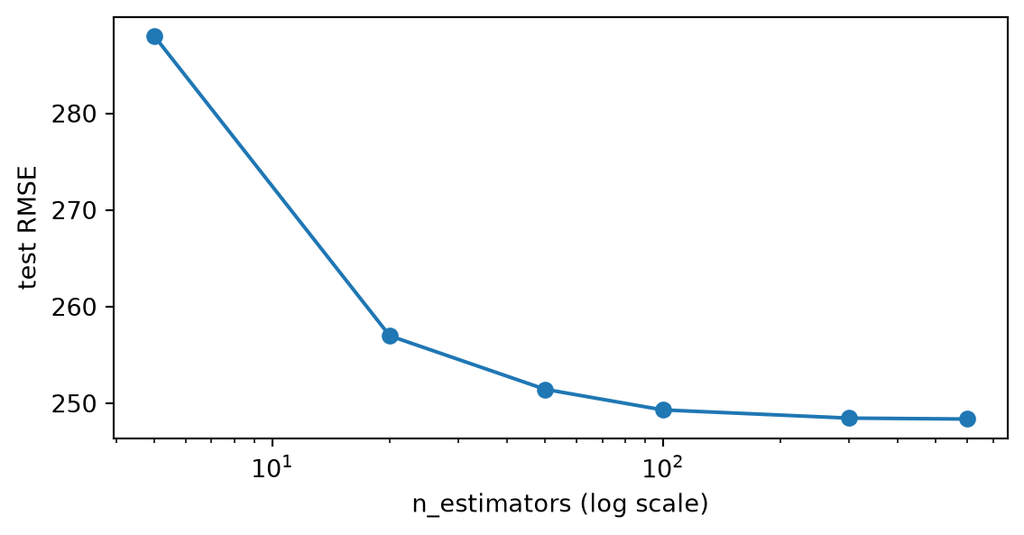

```python
counts = [5, 20, 50, 100, 300, 600]
curve = []
for n in counts:
    r = RandomForestRegressor(n_estimators=n, random_state=RANDOM_STATE, n_jobs=-1).fit(X_train, y_train)
    curve.append(rmse(y_test, r.predict(X_test)))

for n, v in zip(counts, curve):
    print(f"  n_estimators={n:<4} test RMSE {v:,.0f}")

fig, ax = plt.subplots(figsize=(6, 3.2))
ax.plot(counts, curve, marker="o")
ax.set_xscale("log"); ax.set_xlabel("n_estimators (log scale)"); ax.set_ylabel("test RMSE")
plt.tight_layout()
```

**Say what the curve does after about fifty trees**, and what that means for how you would spend a compute budget. More trees never *hurt* accuracy — but every one costs time to fit and to predict.

# Step 3 — The “random” in Random Forest

Bagging alone gives every tree a different sample of *rows*. A Random Forest also gives each split a different random subset of *columns* — `max_features`. Lecture 5 argued this decorrelates the trees, so their errors cancel more completely when averaged.

Test it.

```python
for mf in [None, 0.6, "sqrt", 0.2]:
    r = RandomForestRegressor(n_estimators=300, max_features=mf,
                              random_state=RANDOM_STATE, n_jobs=-1).fit(X_train, y_train)
    label = "all features" if mf is None else str(mf)
    print(f"  max_features={label:<13} test RMSE {rmse(y_test, r.predict(X_test)):,.0f}")
```

```
  max_features=all features  test RMSE 248
  max_features=0.6           test RMSE 247
  max_features=sqrt          test RMSE 254
  max_features=0.2           test RMSE 257
```

**The textbook rule does not win here, and you should know why**

`max_features="sqrt"` is the standard recommendation, and on this dataset it is **worse** than using every feature. That is not a bug — it is the rule meeting its own boundary condition.

You have 10 features, and one of them (`dow`) carries most of the signal. `sqrt(10)` is about 3, so at any given split most trees are not even allowed to *look* at day-of-week. Decorrelation is only a bargain when you have enough redundant, correlated features that losing a few at each split costs you little.

In Homework 3 you will run a forest on 27 features with no single dominant one. Check whether the ranking flips there. **The lesson is the condition, not the default.**

# Step 4 — Validation for free

Each bootstrap sample leaves out about a third of the rows. Those out-of-bag rows never trained that tree, so they can score it — a validation estimate with no holdout set.

```python
rf_oob = RandomForestRegressor(n_estimators=300, oob_score=True,
                               random_state=RANDOM_STATE, n_jobs=-1).fit(X_train, y_train)

oob_rmse = rmse(y_train, rf_oob.oob_prediction_)
print(f"OOB R²   : {rf_oob.oob_score_:.3f}")
print(f"OOB RMSE : {oob_rmse:,.0f}")
print(f"test RMSE: {rmse(y_test, rf_oob.predict(X_test)):,.0f}")
```

```
OOB R²   : 0.809
OOB RMSE : 297
test RMSE: 248
```

**Compare the two numbers and account for the gap.** The OOB estimate is computed on training-period rows scattered through 2012–2015; the test RMSE is a solid block of the final year. Which one would you quote to someone asking how the model will do next month, and why?

# Step 5 — Two importances, two different answers

```python
mdi = pd.Series(rf.feature_importances_, index=FEATURES)

perm = permutation_importance(rf, X_test, y_test, n_repeats=10,
                              random_state=RANDOM_STATE, n_jobs=-1,
                              scoring="neg_root_mean_squared_error")
perm_imp = pd.Series(perm.importances_mean, index=FEATURES)

comp = pd.DataFrame({"MDI": mdi.round(3), "permutation_ΔRMSE": perm_imp.round(1)})
comp["MDI_rank"] = comp.MDI.rank(ascending=False).astype(int)
comp["perm_rank"] = comp["permutation_ΔRMSE"].rank(ascending=False).astype(int)
print(comp.sort_values("MDI", ascending=False).to_string())
```

```
                MDI  permutation_ΔRMSE  MDI_rank  perm_rank
dow           0.583              284.2         1          1
units_lag28   0.119               36.8         2          4
units_lag1    0.086              116.9         3          2
units_lag7    0.053               35.6         4          5
units_lag365  0.036               10.2         5          8
doy           0.036               18.1         5          7
units_lag14   0.031                7.7         7          9
snap          0.027               40.4         8          3
avg_price     0.017                0.0         9         10
is_event      0.012               22.3        10          6
```

Permutation importance is in **units of RMSE**: shuffle that column on the test set, and this is how much worse the forecast gets. That is directly interpretable in a way MDI is not.

**Find the disagreements.** Three are worth naming before you read on:

- one lag that MDI ranks *above* `units_lag1`, while permutation ranks it far below
- `snap`, which MDI places near the bottom and permutation places near the top
- `avg_price` against `is_event`: MDI ranks the price column *above* the event flag, while permutation scores price at exactly zero and the event flag at 22 units of RMSE

**Your turn:** plot the two rankings side by side as horizontal bar charts so the disagreements are visible at a glance.

```python
# ---- your turn: uncomment and fill in the two blanks ----
# fig, axes = plt.subplots(1, 2, figsize=(11, 3.5))
# mdi.sort_values().plot.barh(ax=axes[0], title="MDI (impurity)")
# ___.sort_values().plot.barh(ax=axes[1], title="Permutation (ΔRMSE)")   # <- which Series?
# plt.tight_layout()
```

# Step 6 — Stop averaging. Start correcting.

A forest builds many trees **in parallel** and averages them. Boosting builds them **in sequence**, each one fitted to what the previous ones got wrong.

The first four rows hold the learning rate fixed and add rounds — the same experiment you ran on the forest in Step 2. The last two change the rate instead.

```python
for lr, n in [(0.1, 100), (0.1, 300), (0.1, 1000), (0.1, 3000),
              (0.3, 100), (0.05, 1000)]:
    m = xgb.XGBRegressor(n_estimators=n, learning_rate=lr, max_depth=4,
                         subsample=0.8, colsample_bytree=0.8,
                         random_state=RANDOM_STATE).fit(X_train, y_train)
    print(f"  lr={lr:<5} n={n:<5} train {rmse(y_train, m.predict(X_train)):5,.0f}"
          f"   test {rmse(y_test, m.predict(X_test)):5,.0f}")
```

```
  lr=0.1   n=100   train   171   test   244
  lr=0.1   n=300   train    95   test   243
  lr=0.1   n=1000  train    19   test   250
  lr=0.1   n=3000  train     0   test   253
  lr=0.3   n=100   train    95   test   238
  lr=0.05  n=1000  train    54   test   239
```

```python
best = xgb.XGBRegressor(n_estimators=100, learning_rate=0.1, max_depth=4,
                        subsample=0.8, colsample_bytree=0.8,
                        random_state=RANDOM_STATE).fit(X_train, y_train)
scoreboard["XGBoost (lr=0.1, 100 trees)"] = rmse(y_test, best.predict(X_test))

print(pd.Series(scoreboard).round(0).astype(int).sort_values(ascending=False).to_string())
```

```
Benchmark (same day last year)       625
Single tree (Lab 4)                  324
20 trees averaged by hand (Lab 4)    266
Random Forest (300 trees)            248
XGBoost (lr=0.1, 100 trees)          244
```

**Read the first four rows as a curve, then compare it with Step 2.** Training error falls to zero. Test error bottoms out around 300 rounds and then **climbs back up** — 3,000 rounds is worse than 100. In Step 2 you added trees to a forest all the way to 600 and it never once hurt.

That is the practical difference between the two ensembles. A forest’s trees are fitted independently and averaged, so extra ones can only sharpen the average. Boosting’s trees are fitted to the previous ensemble’s *residuals*, so extra ones keep going — eventually correcting noise. `n_estimators` is a free choice in a forest and a tuning parameter in boosting.

The last two rows say the obvious complement: a big rate with few rounds and a small rate with many land in much the same place, because roughly it is the product that sets the budget. What you cannot do is set a rate and then let the rounds run.

Note which configuration we put on the scoreboard below — `lr=0.1, n=100`, the conventional default, **not** the row with the best test RMSE. Picking the winner out of a column computed on the test set is the mistake Lecture 1 warned about, and it does not stop being a mistake because the grid is small.

# Before you leave

Your scoreboard should run from a benchmark near 625 down to roughly 245, across five models fitted to one series.

> **Discuss (the ranking):** Boosting beat the forest here. Name one property of *this* dataset that favors boosting, and one situation where you would still reach for the forest first — thinking about tuning effort and about what happens when nobody retunes the model for a year.

> **Discuss (the importances):** You have two importance tables that disagree about `snap`. A category manager asks whether SNAP timing matters for stocking. Which table do you show them, what do you say, and what would you want to check before committing to an answer?

> **Discuss (the whole arc):** Across Labs 4 and 5 the RMSE fell from 324 to about 245 on the same series with the same features. What was actually purchased with that improvement, and what was given up along the way? Be specific about the thing you can no longer do that you could do in Step 1 of Lab 4.

*Solutions posted to Canvas after class.*